# Single Cell RNA Sequencing Analysis

Itay Nethanel Gal

1/5/23

## Introduction

This notebook presents a walk through of Single Cell RNA Sequencing (scRNA-seq) data analysis. The advent of scRNA-seq technology has revolutionized the study of biology by enabling the examination of gene expression at the resolution of individual cells. By profiling gene expression across thousands of cells simultaneously, we can unravel the heterogeneity within a population of cells, identify novel cell types, and infer developmental trajectories.

We will use R, a language and environment for statistical computing and graphics, which is particularly well-suited to this type of data thanks to a rich ecosystem of libraries developed specifically for bioinformatics and computational biology. Some of the key packages we’ll be utilizing in our analysis are `Seurat` for scRNA-seq data processing and analysis, `ggplot2` for data visualization, and `SingleCellExperiment` for managing single-cell experiment data.

Importing Libs:

```r
library(dplyr)
library(Seurat)
library(patchwork)
```

Getting the dataset:

```r
# Load the PBMC dataset
getwd()
```

```
[1] "C:/Users/galle/OneDrive/Desktop/Directories/Study/ShanaC/SemB/ML R/Hw/Hw2"
```

```r
pbmc.data <- Read10X(data.dir = "Prod/")
# Initialize the Seurat object with the raw (non-normalized data).
pbmc <- CreateSeuratObject(counts = pbmc.data, project = "pbmc3k", min.cells = 3, min.features = 200)
pbmc
```

```
An object of class Seurat
22017 features across 10119 samples within 1 assay
Active assay: RNA (22017 features, 0 variable features)
```

```r
# Lets examine a few genes in the first thirty cells
pbmc.data[c("CD3D","TCL1A","MS4A1"), 1:30]
```

```
3 x 30 sparse Matrix of class "dgCMatrix"
```

```
  [[ suppressing 30 column names ‘AAACCCACATAACTCG-1’, ‘AAACCCACATGTAACC-1’, ‘AAACCCAGTGAGTCAG-1’ ... ]]
```

```
CD3D  4 . . . . 1 6 . . 4 . . 10 2 6 9 . 7 1 . . . . . . 3 2 4 6 8
TCL1A . 8 . . 1 . . . . . 6 .  . . . . . . . . . . . . . . . . . .
MS4A1 . 9 . . 2 . . . . 1 4 .  . . . . . . . . . . . . . . . 1 . .
```

- Here, we’re going to extract the percentage of mitochondrial genes. Generally, dead cells present a high percentage of mitochondrial genes, so this analysis will help us determine whether our cells are alive or dead
- We use the set of all genes starting with `MT-` as a set of mitochondrial genes

```r
# The [[ operator can add columns to object metadata. This is a great place to stash QC stats

pbmc[["percent.mt"]] <- PercentageFeatureSet(pbmc, pattern = "^MT-")
```

```r
# Show QC metrics for the first 5 cells
head(pbmc@meta.data, 5)
```

|  | orig.ident | nCount_RNA | nFeature_RNA | percent.mt |
| --- | --- | --- | --- | --- |
| AAACCCACATAACTCG-1 | pbmc3k | 22575 | 4803 | 5.333333 |
| AAACCCACATGTAACC-1 | pbmc3k | 7757 | 2232 | 8.843625 |
| AAACCCAGTGAGTCAG-1 | pbmc3k | 21733 | 4324 | 6.322183 |
| AAACCCAGTGCTTATG-1 | pbmc3k | 860 | 343 | 31.511628 |
| AAACGAACAGTCAGTT-1 | pbmc3k | 15310 | 4142 | 7.909863 |

Here we are plotting the following information:

First Plot: 1. nFeature_RNA - Each black dot represent a cell and the Y axis represent the number of genes in each cell 2. nCount_RNA - Each black dot represent a cell and the Y axis represent the number of molecules in each cell 3. precent.mt - Each black dot represent a cell and the Y axis represent the percentage of mitochondrial genes (High means Bad - We will set cutoff to 5%-10%)

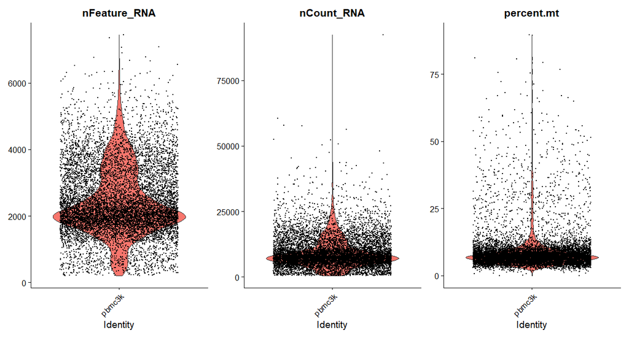

```r
#Visualize QC metrics as a violin plot
VlnPlot(pbmc, features = c("nFeature_RNA", "nCount_RNA", "percent.mt"), ncol = 3)
```

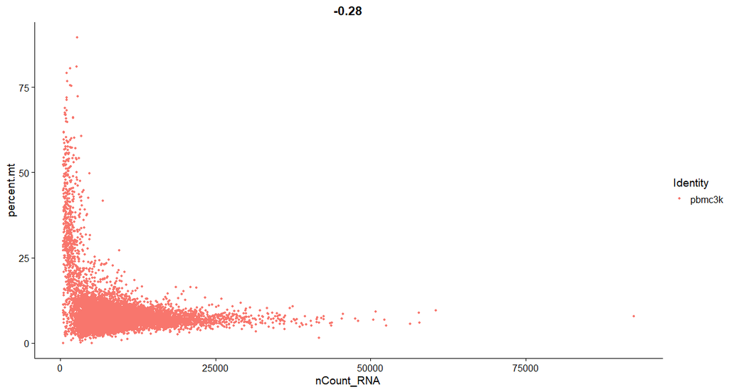

```r
# FeatureScatter is typically used to visualize feature-feature relationships, but can be used for anything calculated by the object, i.e. columns in object metadata, PC scores etc.
plot1 <- FeatureScatter(pbmc, feature1 = "nCount_RNA", feature2 = "percent.mt")
plot2 <- FeatureScatter(pbmc, feature1 = "nCount_RNA", feature2 = "nFeature_RNA")
plot1
```

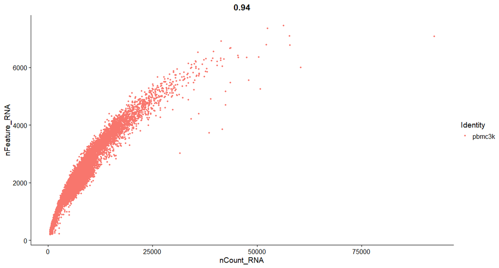

```r
plot2
```

Filtering Out bad samples based on the Violin plots:

```r
pbmc <- subset(pbmc, subset = nFeature_RNA > 1000 & nFeature_RNA < 2500 & percent.mt < 10)
```

Adding Normalization layer to our data:

```r
pbmc <- NormalizeData(pbmc, normalization.method = "LogNormalize", scale.factor = 10000)
```

```r
pbmc <- FindVariableFeatures(pbmc, selection.method = 'vst', nfeatures = 2000)
# Identify the 10 most highly variable genes
top10 <- head(VariableFeatures(pbmc), 10)
# plot variable features with and without labels
plot1 <- VariableFeaturePlot(pbmc)
plot2 <- LabelPoints(plot = plot1, points = top10, repel = TRUE)
```

```
When using repel, set xnudge and ynudge to 0 for optimal results
```

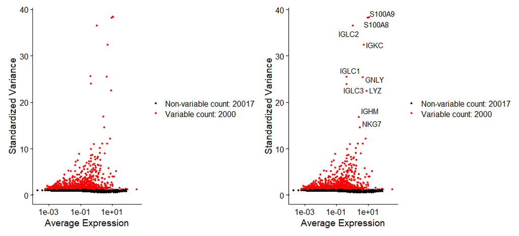

```r
plot1 + plot2
```

```r
all.genes <- rownames(pbmc)
pbmc <- ScaleData(pbmc, features = all.genes)
```

```r
pbmc <- RunPCA(pbmc, features = VariableFeatures(object = pbmc))
```

```r
# Examine and visualize PCA results a few different ways
print(pbmc[['pca']], dims = 1:5, nfeatures = 5)
```

```
PC_ 1
Positive:  RPS18, RPS12, RPS4X, RPS6, EEF1A1
Negative:  MNDA, FCN1, CST3, S100A8, FGL2
PC_ 2
Positive:  HCST, GIMAP7, IL32, CD3D, TRAC
Negative:  MS4A1, CD79A, BANK1, IGHM, HLA-DQA1
PC_ 3
Positive:  EEF1A1, RPS12, SELL, LDHB, CCR7
Negative:  NKG7, CST7, GNLY, PRF1, GZMA
PC_ 4
Positive:  ITGB1, CRIP1, KLF6, TRADD, TNFRSF4
Negative:  KLRK1, CD8B, LINC02446, CCR7, NUCB2
PC_ 5
Positive:  IFITM3, CXCL10, MS4A7, ISG15, SERPING1
Negative:  PADI4, CES1, MCEMP1, CYP1B1, MGST1
```

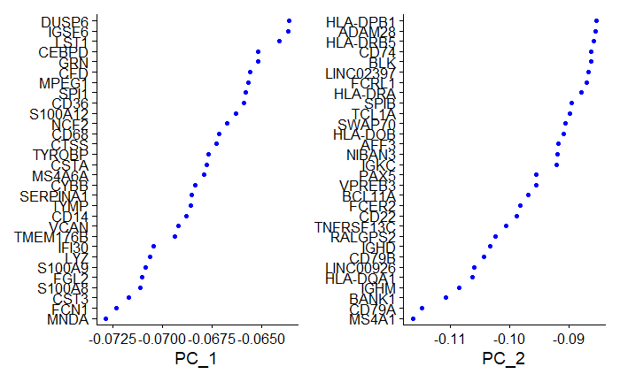

```r
VizDimLoadings(pbmc, dims = 1:2, reduction = 'pca')
```

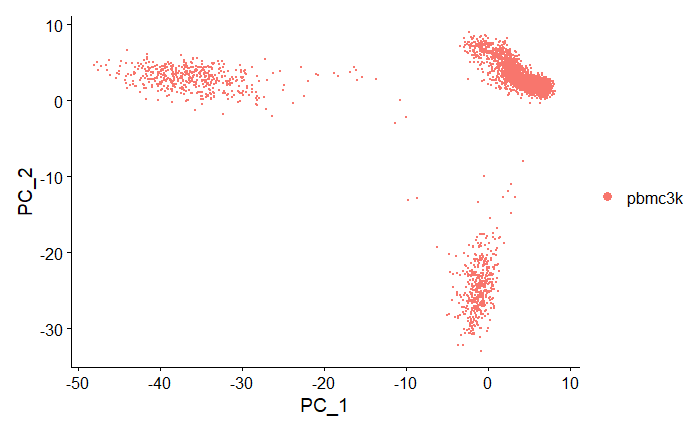

```r
DimPlot(pbmc, reduction = 'pca')
```

Plotting an HeatMap for PC1. We want the squares to be much destinguish and seperate from each other which lead to more tendency to pick up this PC for our using

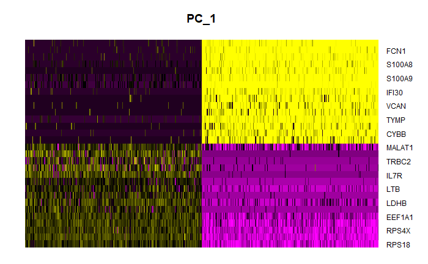

```r
DimHeatmap(pbmc, dims = 1, cells = 500, balanced = TRUE)
```

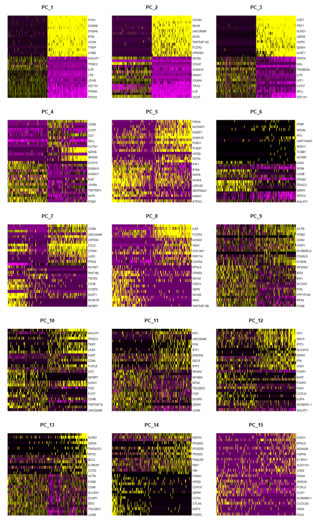

```r
DimHeatmap(pbmc, dims = 1:15, cells = 500, balanced = TRUE)
```